# §2.1a — Constellations

Unit 2: The Night Sky · Astronomy

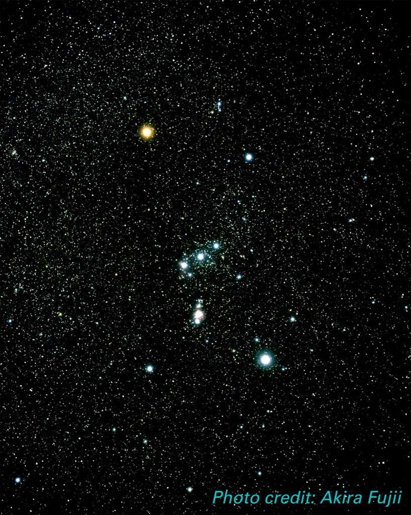

Go outside at about 9 pm next week and look east. A bright **red** star comes up first, then three stars in a perfectly straight row, then a brilliant **blue-white** star below them. That is **Orion**, the Hunter, and the fuzzy pink patch under the row is a cloud where new stars are being born.

On a dark night you can see about 3000 stars at once. How do astronomers keep track of them all, and how do you say exactly where one is, so that someone across the world can point a telescope at it?

Today: the constellations, the celestial sphere, and the address of every star (RA and Dec).

Orion. Photo: Akira Fujii, via ESA/Hubble (CC BY 4.0)

## 1 · The sky at a glance

✨

about 3000

Stars you can see at once

on a dark night, far from city lights

🗺️

88

Constellations

set by the International Astronomical Union in 1930; they cover the whole sky

🕐

Right Ascension

measured in hours, so each hour is 15°

📐

Astronomical angles

degrees, arcminutes, arcseconds

⭐

Polaris to the pole

less than 1½ Moon-widths from the North Celestial Pole

## 2 · Constellations and the celestial sphere

Click a tile. The first three are about the constellations; the last three are about finding any star by its address.

[figure not shown]

1

Constellations

connect the dots

[figure not shown]

2

Careful!

close in the sky, not in space

[figure not shown]

3

88 Constellations

areas of the sky

[figure not shown]

4

The Celestial Sphere

CE, NCP and SCP

[figure not shown]

5

The Equatorial System

RA and Dec

[figure not shown]

6

Astronomical Angles

degrees, ′ and ″

← scroll the tiles →

[figure not shown]

### Constellations

People have always grouped the bright stars into pictures. Those groups are the **constellations**. The Greeks saw Orion as a hunter, with a raised club, a shield, and a belt of three stars. Before you see anyone else's picture, make your own.

Orion: connect the dots, then compare

[interactive chart not shown]

Explore around Orion in skymap ↗

Click one star, then another, to draw a line between them. Draw your own figure first.

Your figure and Rey's are both fine. A constellation's **stick figure** is just a way to remember it; what you have to know for the Night Sky quiz is where it is, its outline, and its abbreviation (Orion is **Ori**).

Measure: how tall is Orion?

Use the Dec lines on the chart. Read the declination of **Betelgeuse** (the red shoulder) and of **Rigel** (the blue foot), and subtract. About how many degrees of declination does Orion span from Betelgeuse to Rigel?

degrees

**Look up.** On Tue Nov 3, Orion's belt rises **due east** at about 8:56 pm from Portland and is highest, due south, at about 2:53 am. Each night it rises about 4 minutes earlier, so by early December it is up before 7 pm. (Computed for Portland with Astronomy Engine.)

### Careful! Close in the sky is not close in space

We see the stars as if they had no depth, all painted on the same dome. Orion's stars only **look** close together because they lie in nearly the same direction. Their distances are very different.

Turn Orion sideways

Predict first: which is closest to us?

[interactive chart not shown]

view fromEarth

Make your prediction first. Then drag the slider to fly around and look at Orion from the side.

Seen from the side, the Hunter falls apart. One shoulder, Bellatrix, is about 250 light-years away; the Belt stars are about 1,300, five times farther. A constellation is a **direction** in the sky, not a group of neighbours.

Measure: when did Betelgeuse's light leave?

Betelgeuse is about 550 light-years away. Light travels one light-year in one year. In about what **year** did the light you see tonight leave Betelgeuse?

year

Distances are rounded, and the same ones skymap uses.

### 88 constellations, which take up area

Since 1930 the **International Astronomical Union** has divided the whole sky into **88 constellations**, with official borders like the states on a map. A constellation is not just its stick figure; it is an **area** of sky. Every star, galaxy and nebula lies inside exactly one of them.

The whole sky, flattened: click anywhere

[interactive chart not shown]

First, find Orion: click where you think Orion's area is. (Hint: it sits on the blue line.)

The map is the whole sky unrolled, like a world map. Left to right is **Right Ascension**, top to bottom is **Declination**, and the blue line is the **celestial equator**. The next tiles explain all three.

Measure: which constellation?

A comet is spotted at RA $= 5^{\rm h}$, Dec $= +45^\circ$. Find that spot on the map (the readout shows where your mouse is). Which constellation is the comet in? Type its name or abbreviation.

### The Celestial Sphere

To help understand how the stars move, astronomers invented **the celestial sphere**: pretend every star is stuck to a huge sphere with Earth at its centre. Three things on it come straight from Earth:

- **Celestial Equator (CE)**: Earth's equator projected onto the celestial sphere.
- **North Celestial Pole (NCP)**: the point directly above Earth's spin axis, out past the North Pole.
- **South Celestial Pole (SCP)**: the point directly below Earth's spin axis.

Earth inside the celestial sphere: drag to turn the view

[interactive chart not shown]

View:

The stars are not really moving. We now know that the **rotation of the Earth** causes the sky to appear to move. Every star circles the NCP once a day, and the closer it is to the pole, the smaller its circle. The star near the NCP is **Polaris**, the North Star.

Measure: how close is Polaris to the pole?

Polaris has a declination of $\delta = +89.26^\circ$, and the NCP is at $+90^\circ$. How many degrees is Polaris from the NCP? The Moon is about $0.5^\circ$ across; how many Moon-widths is that?

degrees

### The Equatorial System

**How do you find the location of a city?** Longitude is east or west of the Prime Meridian; latitude is north or south of the Equator.

**How do you find the location of a star?** The same way, on the celestial sphere: **Right Ascension is like longitude** and **Declination is like latitude**.

**RA = Right Ascension** ($\alpha$). Given in time units, e.g. $\alpha = 12^{\rm h}34^{\rm m}56^{\rm s}$. There are $24^{\rm h}$ in the complete celestial sphere, so $1^{\rm h} = 15^\circ$. RA $= 0^{\rm h}$ is the **First Point of Aries**, ♈ (the vernal equinox).

**Dec = Declination** ($\delta$). Given in degrees, arcminutes and arcseconds, e.g. $\delta = +12^\circ 34' 56''$. Celestial Equator $= 0^\circ$, NCP $= +90^\circ$, SCP $= -90^\circ$.

The Sun's yearly path around the sky is the **ecliptic**. It is tilted $23.5^\circ$ to the celestial equator, because Earth's axis is tilted. The two lines cross at ♈, where RA starts, and again at $12^{\rm h}$. (Remember from §1.4b: the Moon's orbit is tilted another $5^\circ$ from the ecliptic.)

**You already know this on Earth.** Turn the Earth and click anywhere for its latitude and longitude. Then turn the sky: the grid is the same idea, with Dec for latitude and RA for longitude.

On Earth: latitude and longitude

[interactive chart not shown]

Portland is at about 45.5° N, 122.7° W. Click anywhere on the Earth.

In the sky: Dec and RA

[interactive chart not shown]

Hour lines run pole to pole and are labelled along the celestial equator. Click a star. A globe shows the sky from outside, so it is mirrored: RA increases to the right here, but to the left on a star chart, which shows the sky as we see it from inside.

**Where the analogy breaks.** Longitude is fixed to the Earth and counts degrees east or west of Greenwich. RA is fixed to the **stars**, counts eastward from ♈ all the way around, and is measured in **hours**: $0^{\rm h}$ to $24^{\rm h}$. As the Earth spins, every longitude passes under every hour of RA once a day.

Quick Quiz: estimate α, δ for the star shown, then name it

View:

[interactive chart not shown]

α estimatehδ estimate°

Read the grid: hours along the bottom, degrees up the side. Enter your estimates, then check.

### Astronomical Angles

$$\text{Whole circle} = 360^\circ$$ $$1^\circ = 60'\ \text{(arcminutes)} \qquad 1' = 60''\ \text{(arcseconds)}$$ To go to decimal degrees, divide arcminutes by 60 and arcseconds by 3600. For RA, turn hours into decimal hours the same way, then multiply by 15.

Zoom into one degree

[interactive chart not shown]

zoom in

Ex. 1

Ex. 4 · Convert (21h45m, +63°15′) to decimal degrees

**Reveal**

$$\alpha = 21 + \frac{45}{60} = 21.75^{\rm h}, \qquad 21.75^{\rm h} \times 15\,\frac{^\circ}{^{\rm h}} = \boxed{326.25^\circ}$$ $$\delta = 63 + \frac{15}{60} = \boxed{+63.25^\circ}$$

Converter: watch each step

°′″

Measure: Betelgeuse's address in degrees

Betelgeuse is at $\alpha = 5^{\rm h}55^{\rm m}10^{\rm s}$, $\delta = +7^\circ 24' 25''$. Convert both to decimal degrees.

α°δ°

## 3 · Self-check

**Next class: learn the fall sky.** The Night Sky quiz (Tue Nov 10) asks you to find constellations, stars and objects on a blank chart for Nov 1 at 10 pm. Practice in **skymap**: Learn, then Quiz with the fall set.

**Sources and further reading**

Want to dig deeper? Each title links straight to the original.

**Constellations**

- [The 88 IAU constellations](https://en.wikipedia.org/wiki/IAU_designated_constellations) (Wikipedia): the full list with abbreviations, sizes and a chart of each one's borders.
- [What are constellations?](https://spaceplace.nasa.gov/constellations/en/) (NASA Space Place): a short, friendly explainer.
- [H.A. Rey's constellation figures](https://github.com/Stellarium/stellarium-skycultures/tree/master/western_rey) (Stellarium): the stick figures used here, from Rey's book *The Stars: A New Way to See Them*.

**How far away are Orion's stars?**

- [The Hipparcos mission](https://www.cosmos.esa.int/web/hipparcos) (ESA): the satellite that measured the distances in the "Careful!" tile.
- [Stars](https://science.nasa.gov/universe/stars/) (NASA): what stars are and how far away they are.

**Borders and coordinates**

- d3-celestial (Olaf Frohn): the star positions and the IAU borders drawn on the whole-sky map.
- [Skywatching](https://science.nasa.gov/skywatching/) (NASA): what's up in the sky each month, with charts.

**Tonight's sky**

- [Astronomy Engine](https://github.com/cosinekitty/astronomy) (Don Cross): the code that computed Orion's rising time for Portland.
- [Orion Constellation](https://esahubble.org/images/opo0205b/) (ESA/Hubble): the photo at the top of this page.

**Image credits**

- Orion: Akira Fujii, via ESA/Hubble, opo0205b (CC BY 4.0).
- Stick figures: after H.A. Rey, from the Stellarium `western_rey` sky culture (CC BY-SA 4.0).
- Stars and borders: Hipparcos and the IAU, via d3-celestial (BSD-3). Star facts and distances: the course's skymap app.
- Earth map: land outlines from Natural Earth, 1:110m (public domain).
- All other figures are drawn on this page.